# Risk Factor Analysis

## Outcome Variable

**Outcome Variable:** ever_wasted

## Predictor Variables

**Intervention Variable:** parity

**Adjustment Set:**

- arm
- W_mage
- meducyrs
- feducyrs
- hhwealth_quart
- W_mhtcm
- vagbrth
- W_nrooms
- impsan
- delta_W_mage
- delta_meducyrs
- delta_feducyrs
- delta_hhwealth_quart
- delta_W_mhtcm
- delta_vagbrth
- delta_W_nrooms
- delta_impsan

## Stratifying Variables

The analysis was stratified on these variable(s):

- agecat
- studyid
- country

## Data Summary

| agecat | studyid | country | parity | ever_wasted | n_cell | n |
| --- | --- | --- | --- | --- | --- | --- |
| 0-24 months | ki1000304b-SAS-CompFeed | INDIA | 1 | 0 | 273 | 1513 |
| 0-24 months | ki1000304b-SAS-CompFeed | INDIA | 1 | 1 | 175 | 1513 |
| 0-24 months | ki1000304b-SAS-CompFeed | INDIA | 2 | 0 | 219 | 1513 |
| 0-24 months | ki1000304b-SAS-CompFeed | INDIA | 2 | 1 | 135 | 1513 |
| 0-24 months | ki1000304b-SAS-CompFeed | INDIA | 3+ | 0 | 393 | 1513 |
| 0-24 months | ki1000304b-SAS-CompFeed | INDIA | 3+ | 1 | 318 | 1513 |
| 0-24 months | ki1000304b-SAS-FoodSuppl | INDIA | 1 | 0 | 51 | 397 |
| 0-24 months | ki1000304b-SAS-FoodSuppl | INDIA | 1 | 1 | 26 | 397 |
| 0-24 months | ki1000304b-SAS-FoodSuppl | INDIA | 2 | 0 | 46 | 397 |
| 0-24 months | ki1000304b-SAS-FoodSuppl | INDIA | 2 | 1 | 46 | 397 |
| 0-24 months | ki1000304b-SAS-FoodSuppl | INDIA | 3+ | 0 | 112 | 397 |
| 0-24 months | ki1000304b-SAS-FoodSuppl | INDIA | 3+ | 1 | 116 | 397 |
| 0-24 months | ki1017093b-PROVIDE | BANGLADESH | 1 | 0 | 163 | 700 |
| 0-24 months | ki1017093b-PROVIDE | BANGLADESH | 1 | 1 | 108 | 700 |
| 0-24 months | ki1017093b-PROVIDE | BANGLADESH | 2 | 0 | 170 | 700 |
| 0-24 months | ki1017093b-PROVIDE | BANGLADESH | 2 | 1 | 74 | 700 |
| 0-24 months | ki1017093b-PROVIDE | BANGLADESH | 3+ | 0 | 121 | 700 |
| 0-24 months | ki1017093b-PROVIDE | BANGLADESH | 3+ | 1 | 64 | 700 |
| 0-24 months | ki1066203-TanzaniaChild2 | TANZANIA, UNITED REPUBLIC OF | 1 | 0 | 624 | 2357 |
| 0-24 months | ki1066203-TanzaniaChild2 | TANZANIA, UNITED REPUBLIC OF | 1 | 1 | 197 | 2357 |
| 0-24 months | ki1066203-TanzaniaChild2 | TANZANIA, UNITED REPUBLIC OF | 2 | 0 | 583 | 2357 |
| 0-24 months | ki1066203-TanzaniaChild2 | TANZANIA, UNITED REPUBLIC OF | 2 | 1 | 188 | 2357 |
| 0-24 months | ki1066203-TanzaniaChild2 | TANZANIA, UNITED REPUBLIC OF | 3+ | 0 | 592 | 2357 |
| 0-24 months | ki1066203-TanzaniaChild2 | TANZANIA, UNITED REPUBLIC OF | 3+ | 1 | 173 | 2357 |
| 0-24 months | ki1101329-Keneba | GAMBIA | 1 | 0 | 160 | 1989 |
| 0-24 months | ki1101329-Keneba | GAMBIA | 1 | 1 | 80 | 1989 |
| 0-24 months | ki1101329-Keneba | GAMBIA | 2 | 0 | 138 | 1989 |
| 0-24 months | ki1101329-Keneba | GAMBIA | 2 | 1 | 76 | 1989 |
| 0-24 months | ki1101329-Keneba | GAMBIA | 3+ | 0 | 887 | 1989 |
| 0-24 months | ki1101329-Keneba | GAMBIA | 3+ | 1 | 648 | 1989 |

[output cut: 168 more lines]

The following strata were considered:

- agecat: 0-24 months, studyid: ki1000304b-SAS-CompFeed, country: INDIA
- agecat: 0-24 months, studyid: ki1000304b-SAS-FoodSuppl, country: INDIA
- agecat: 0-24 months, studyid: ki1017093b-PROVIDE, country: BANGLADESH
- agecat: 0-24 months, studyid: ki1066203-TanzaniaChild2, country: TANZANIA, UNITED REPUBLIC OF
- agecat: 0-24 months, studyid: ki1101329-Keneba, country: GAMBIA
- agecat: 0-24 months, studyid: ki1113344-GMS-Nepal, country: NEPAL
- agecat: 0-24 months, studyid: ki1126311-ZVITAMBO, country: ZIMBABWE
- agecat: 0-24 months, studyid: ki1135781-COHORTS, country: GUATEMALA
- agecat: 0-24 months, studyid: ki1135781-COHORTS, country: INDIA
- agecat: 0-24 months, studyid: ki1135781-COHORTS, country: PHILIPPINES
- agecat: 0-24 months, studyid: kiGH5241-JiVitA-3, country: BANGLADESH
- agecat: 0-6 months, studyid: ki1000304b-SAS-CompFeed, country: INDIA
- agecat: 0-6 months, studyid: ki1000304b-SAS-FoodSuppl, country: INDIA
- agecat: 0-6 months, studyid: ki1017093b-PROVIDE, country: BANGLADESH
- agecat: 0-6 months, studyid: ki1066203-TanzaniaChild2, country: TANZANIA, UNITED REPUBLIC OF
- agecat: 0-6 months, studyid: ki1101329-Keneba, country: GAMBIA
- agecat: 0-6 months, studyid: ki1113344-GMS-Nepal, country: NEPAL
- agecat: 0-6 months, studyid: ki1126311-ZVITAMBO, country: ZIMBABWE
- agecat: 0-6 months, studyid: ki1135781-COHORTS, country: GUATEMALA
- agecat: 0-6 months, studyid: ki1135781-COHORTS, country: INDIA
- agecat: 0-6 months, studyid: ki1135781-COHORTS, country: PHILIPPINES
- agecat: 0-6 months, studyid: kiGH5241-JiVitA-3, country: BANGLADESH
- agecat: 6-24 months, studyid: ki1000304b-SAS-CompFeed, country: INDIA
- agecat: 6-24 months, studyid: ki1000304b-SAS-FoodSuppl, country: INDIA
- agecat: 6-24 months, studyid: ki1017093b-PROVIDE, country: BANGLADESH
- agecat: 6-24 months, studyid: ki1066203-TanzaniaChild2, country: TANZANIA, UNITED REPUBLIC OF
- agecat: 6-24 months, studyid: ki1101329-Keneba, country: GAMBIA
- agecat: 6-24 months, studyid: ki1113344-GMS-Nepal, country: NEPAL
- agecat: 6-24 months, studyid: ki1126311-ZVITAMBO, country: ZIMBABWE
- agecat: 6-24 months, studyid: ki1135781-COHORTS, country: GUATEMALA
- agecat: 6-24 months, studyid: ki1135781-COHORTS, country: INDIA
- agecat: 6-24 months, studyid: ki1135781-COHORTS, country: PHILIPPINES
- agecat: 6-24 months, studyid: kiGH5241-JiVitA-3, country: BANGLADESH

## Methods Detail

We’re interested in the causal parameters $E[Y_a]$ for all values of $a \in \mathcal{A}$. These parameters represent the mean outcome if, possibly contrary to fact, we intervened to set all units to have $A=a$. Under the randomization and positivity assumptions, these are identified by the statistical parameters $\psi_a=E_W[E_{Y|A,W}(Y|A=a,W)]$. In addition, we’re interested in the mean of $Y$, $E[Y]$ under no intervention (the observed mean). We will estimate these parameters by using SuperLearner to fit the relevant likelihood factors – $E_{Y|A,W}(Y|A=a,W)$ and $p(A=a|W)$, and then updating our likelihood fit using a joint TMLE.

For unadjusted analyses ($W=\{\}$), initial likelihoods were estimated using Lrnr_glm to estimate the simple $E(Y|A)$ and Lrnr_mean to estimate $p(A)$. For adjusted analyses, a small library containing Lrnr_glmnet, Lrnr_xgboost, and Lrnr_mean was used.

Having estimated these parameters, we will then use the delta method to estimate relative risks and attributable risks relative to a prespecified baseline level of $A$.

# Results Detail

## Results Plots

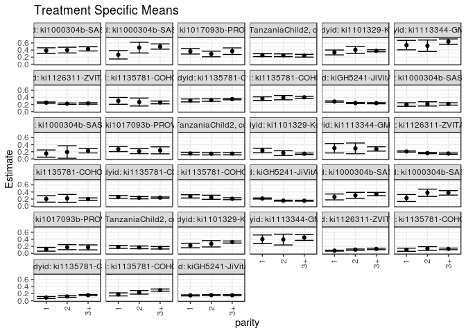

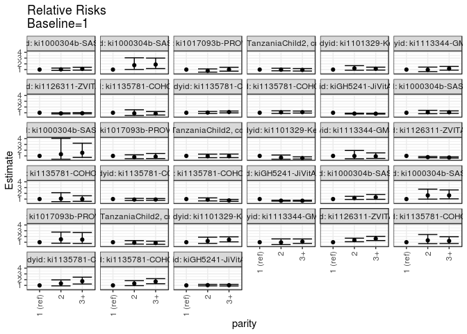

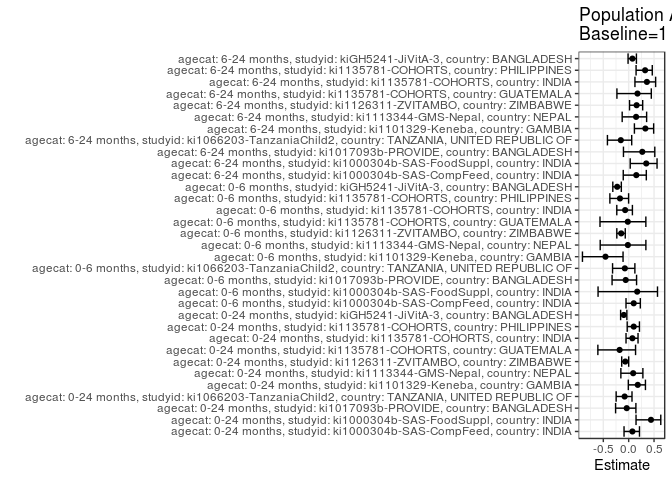

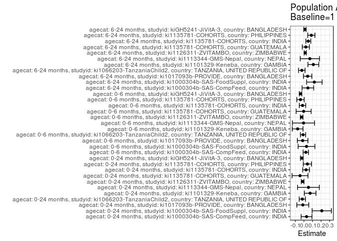

## Results Table

### Parameter: TSM

| agecat | studyid | country | intervention_level | baseline_level | estimate | ci_lower | ci_upper |
| --- | --- | --- | --- | --- | --- | --- | --- |
| 0-24 months | ki1000304b-SAS-CompFeed | INDIA | 1 | NA | 0.3845938 | 0.3058615 | 0.4633260 |
| 0-24 months | ki1000304b-SAS-CompFeed | INDIA | 2 | NA | 0.3989501 | 0.3185559 | 0.4793443 |
| 0-24 months | ki1000304b-SAS-CompFeed | INDIA | 3+ | NA | 0.4330229 | 0.3735035 | 0.4925422 |
| 0-24 months | ki1000304b-SAS-FoodSuppl | INDIA | 1 | NA | 0.2652738 | 0.1476724 | 0.3828751 |
| 0-24 months | ki1000304b-SAS-FoodSuppl | INDIA | 2 | NA | 0.4686278 | 0.3177414 | 0.6195143 |
| 0-24 months | ki1000304b-SAS-FoodSuppl | INDIA | 3+ | NA | 0.4990589 | 0.4252861 | 0.5728318 |
| 0-24 months | ki1017093b-PROVIDE | BANGLADESH | 1 | NA | 0.3649918 | 0.2868570 | 0.4431267 |
| 0-24 months | ki1017093b-PROVIDE | BANGLADESH | 2 | NA | 0.2879997 | 0.2097920 | 0.3662074 |
| 0-24 months | ki1017093b-PROVIDE | BANGLADESH | 3+ | NA | 0.3680483 | 0.2752305 | 0.4608662 |
| 0-24 months | ki1066203-TanzaniaChild2 | TANZANIA, UNITED REPUBLIC OF | 1 | NA | 0.2555624 | 0.2145266 | 0.2965981 |
| 0-24 months | ki1066203-TanzaniaChild2 | TANZANIA, UNITED REPUBLIC OF | 2 | NA | 0.2516955 | 0.2123010 | 0.2910900 |
| 0-24 months | ki1066203-TanzaniaChild2 | TANZANIA, UNITED REPUBLIC OF | 3+ | NA | 0.2397385 | 0.2006887 | 0.2787884 |
| 0-24 months | ki1101329-Keneba | GAMBIA | 1 | NA | 0.3318727 | 0.2631571 | 0.4005882 |
| 0-24 months | ki1101329-Keneba | GAMBIA | 2 | NA | 0.4045921 | 0.3053792 | 0.5038050 |
| 0-24 months | ki1101329-Keneba | GAMBIA | 3+ | NA | 0.3785041 | 0.3503892 | 0.4066189 |
| 0-24 months | ki1113344-GMS-Nepal | NEPAL | 1 | NA | 0.5389002 | 0.4059513 | 0.6718490 |
| 0-24 months | ki1113344-GMS-Nepal | NEPAL | 2 | NA | 0.5193457 | 0.3572706 | 0.6814207 |
| 0-24 months | ki1113344-GMS-Nepal | NEPAL | 3+ | NA | 0.6366468 | 0.5594428 | 0.7138509 |
| 0-24 months | ki1126311-ZVITAMBO | ZIMBABWE | 1 | NA | 0.2503259 | 0.2326785 | 0.2679733 |
| 0-24 months | ki1126311-ZVITAMBO | ZIMBABWE | 2 | NA | 0.2216073 | 0.2020541 | 0.2411605 |
| 0-24 months | ki1126311-ZVITAMBO | ZIMBABWE | 3+ | NA | 0.2290929 | 0.2081106 | 0.2500751 |
| 0-24 months | ki1135781-COHORTS | GUATEMALA | 1 | NA | 0.3005742 | 0.2050674 | 0.3960810 |
| 0-24 months | ki1135781-COHORTS | GUATEMALA | 2 | NA | 0.2680892 | 0.1549977 | 0.3811808 |
| 0-24 months | ki1135781-COHORTS | GUATEMALA | 3+ | NA | 0.2568640 | 0.2184536 | 0.2952744 |
| 0-24 months | ki1135781-COHORTS | INDIA | 1 | NA | 0.3129219 | 0.2711270 | 0.3547167 |
| 0-24 months | ki1135781-COHORTS | INDIA | 2 | NA | 0.3231823 | 0.2880694 | 0.3582951 |
| 0-24 months | ki1135781-COHORTS | INDIA | 3+ | NA | 0.3514391 | 0.3308587 | 0.3720195 |
| 0-24 months | ki1135781-COHORTS | PHILIPPINES | 1 | NA | 0.3633775 | 0.3122316 | 0.4145234 |
| 0-24 months | ki1135781-COHORTS | PHILIPPINES | 2 | NA | 0.3921957 | 0.3315884 | 0.4528029 |
| 0-24 months | ki1135781-COHORTS | PHILIPPINES | 3+ | NA | 0.4012420 | 0.3716669 | 0.4308171 |

[output cut: 69 more lines]

### Parameter: E(Y)

| agecat | studyid | country | intervention_level | baseline_level | estimate | ci_lower | ci_upper |
| --- | --- | --- | --- | --- | --- | --- | --- |
| 0-24 months | ki1000304b-SAS-CompFeed | INDIA | NA | NA | 0.4150694 | 0.3581204 | 0.4720184 |
| 0-24 months | ki1000304b-SAS-FoodSuppl | INDIA | NA | NA | 0.4735516 | 0.4243746 | 0.5227286 |
| 0-24 months | ki1017093b-PROVIDE | BANGLADESH | NA | NA | 0.3514286 | 0.3160364 | 0.3868207 |
| 0-24 months | ki1066203-TanzaniaChild2 | TANZANIA, UNITED REPUBLIC OF | NA | NA | 0.2367416 | 0.2195770 | 0.2539062 |
| 0-24 months | ki1101329-Keneba | GAMBIA | NA | NA | 0.4042232 | 0.3826511 | 0.4257953 |
| 0-24 months | ki1113344-GMS-Nepal | NEPAL | NA | NA | 0.5913621 | 0.5520608 | 0.6306634 |
| 0-24 months | ki1126311-ZVITAMBO | ZIMBABWE | NA | NA | 0.2347539 | 0.2277172 | 0.2417906 |
| 0-24 months | ki1135781-COHORTS | GUATEMALA | NA | NA | 0.2550336 | 0.2316956 | 0.2783715 |
| 0-24 months | ki1135781-COHORTS | INDIA | NA | NA | 0.3378028 | 0.3241691 | 0.3514364 |
| 0-24 months | ki1135781-COHORTS | PHILIPPINES | NA | NA | 0.4036125 | 0.3861835 | 0.4210415 |
| 0-24 months | kiGH5241-JiVitA-3 | BANGLADESH | NA | NA | 0.2580286 | 0.2515670 | 0.2644901 |
| 0-6 months | ki1000304b-SAS-CompFeed | INDIA | NA | NA | 0.2199336 | 0.1753445 | 0.2645227 |
| 0-6 months | ki1000304b-SAS-FoodSuppl | INDIA | NA | NA | 0.1788413 | 0.1410973 | 0.2165853 |
| 0-6 months | ki1017093b-PROVIDE | BANGLADESH | NA | NA | 0.2585714 | 0.2261125 | 0.2910304 |
| 0-6 months | ki1066203-TanzaniaChild2 | TANZANIA, UNITED REPUBLIC OF | NA | NA | 0.1395842 | 0.1255905 | 0.1535779 |
| 0-6 months | ki1101329-Keneba | GAMBIA | NA | NA | 0.1613611 | 0.1444653 | 0.1782570 |
| 0-6 months | ki1113344-GMS-Nepal | NEPAL | NA | NA | 0.2956811 | 0.2591967 | 0.3321655 |
| 0-6 months | ki1126311-ZVITAMBO | ZIMBABWE | NA | NA | 0.1810631 | 0.1746489 | 0.1874773 |
| 0-6 months | ki1135781-COHORTS | GUATEMALA | NA | NA | 0.2003763 | 0.1763021 | 0.2244505 |
| 0-6 months | ki1135781-COHORTS | INDIA | NA | NA | 0.2434743 | 0.2308547 | 0.2560940 |
| 0-6 months | ki1135781-COHORTS | PHILIPPINES | NA | NA | 0.2355453 | 0.2204685 | 0.2506222 |
| 0-6 months | kiGH5241-JiVitA-3 | BANGLADESH | NA | NA | 0.1762799 | 0.1706566 | 0.1819032 |
| 6-24 months | ki1000304b-SAS-CompFeed | INDIA | NA | NA | 0.3059755 | 0.2638053 | 0.3481458 |
| 6-24 months | ki1000304b-SAS-FoodSuppl | INDIA | NA | NA | 0.3518987 | 0.3047435 | 0.3990540 |
| 6-24 months | ki1017093b-PROVIDE | BANGLADESH | NA | NA | 0.1609756 | 0.1319065 | 0.1900447 |
| 6-24 months | ki1066203-TanzaniaChild2 | TANZANIA, UNITED REPUBLIC OF | NA | NA | 0.1600403 | 0.1439152 | 0.1761654 |
| 6-24 months | ki1101329-Keneba | GAMBIA | NA | NA | 0.3341996 | 0.3131165 | 0.3552826 |
| 6-24 months | ki1113344-GMS-Nepal | NEPAL | NA | NA | 0.4728814 | 0.4325613 | 0.5132014 |
| 6-24 months | ki1126311-ZVITAMBO | ZIMBABWE | NA | NA | 0.0939867 | 0.0884555 | 0.0995179 |
| 6-24 months | ki1135781-COHORTS | GUATEMALA | NA | NA | 0.1269580 | 0.1082147 | 0.1457012 |
| 6-24 months | ki1135781-COHORTS | INDIA | NA | NA | 0.1419682 | 0.1315821 | 0.1523542 |
| 6-24 months | ki1135781-COHORTS | PHILIPPINES | NA | NA | 0.2666429 | 0.2502871 | 0.2829988 |
| 6-24 months | kiGH5241-JiVitA-3 | BANGLADESH | NA | NA | 0.1638036 | 0.1576801 | 0.1699271 |

### Parameter: RR

| agecat | studyid | country | intervention_level | baseline_level | estimate | ci_lower | ci_upper |
| --- | --- | --- | --- | --- | --- | --- | --- |
| 0-24 months | ki1000304b-SAS-CompFeed | INDIA | 1 | 1 | 1.0000000 | 1.0000000 | 1.0000000 |
| 0-24 months | ki1000304b-SAS-CompFeed | INDIA | 2 | 1 | 1.0373286 | 0.8555510 | 1.2577282 |
| 0-24 months | ki1000304b-SAS-CompFeed | INDIA | 3+ | 1 | 1.1259228 | 0.9029538 | 1.4039500 |
| 0-24 months | ki1000304b-SAS-FoodSuppl | INDIA | 1 | 1 | 1.0000000 | 1.0000000 | 1.0000000 |
| 0-24 months | ki1000304b-SAS-FoodSuppl | INDIA | 2 | 1 | 1.7665820 | 1.0229520 | 3.0507900 |
| 0-24 months | ki1000304b-SAS-FoodSuppl | INDIA | 3+ | 1 | 1.8812978 | 1.1789422 | 3.0020821 |
| 0-24 months | ki1017093b-PROVIDE | BANGLADESH | 1 | 1 | 1.0000000 | 1.0000000 | 1.0000000 |
| 0-24 months | ki1017093b-PROVIDE | BANGLADESH | 2 | 1 | 0.7890580 | 0.5585475 | 1.1146992 |
| 0-24 months | ki1017093b-PROVIDE | BANGLADESH | 3+ | 1 | 1.0083742 | 0.7245764 | 1.4033283 |
| 0-24 months | ki1066203-TanzaniaChild2 | TANZANIA, UNITED REPUBLIC OF | 1 | 1 | 1.0000000 | 1.0000000 | 1.0000000 |
| 0-24 months | ki1066203-TanzaniaChild2 | TANZANIA, UNITED REPUBLIC OF | 2 | 1 | 0.9848692 | 0.7872116 | 1.2321558 |
| 0-24 months | ki1066203-TanzaniaChild2 | TANZANIA, UNITED REPUBLIC OF | 3+ | 1 | 0.9380824 | 0.7462298 | 1.1792594 |
| 0-24 months | ki1101329-Keneba | GAMBIA | 1 | 1 | 1.0000000 | 1.0000000 | 1.0000000 |
| 0-24 months | ki1101329-Keneba | GAMBIA | 2 | 1 | 1.2191185 | 0.8842857 | 1.6807348 |
| 0-24 months | ki1101329-Keneba | GAMBIA | 3+ | 1 | 1.1405099 | 0.9155400 | 1.4207603 |
| 0-24 months | ki1113344-GMS-Nepal | NEPAL | 1 | 1 | 1.0000000 | 1.0000000 | 1.0000000 |
| 0-24 months | ki1113344-GMS-Nepal | NEPAL | 2 | 1 | 0.9637140 | 0.6474752 | 1.4344097 |
| 0-24 months | ki1113344-GMS-Nepal | NEPAL | 3+ | 1 | 1.1813818 | 0.8975799 | 1.5549178 |
| 0-24 months | ki1126311-ZVITAMBO | ZIMBABWE | 1 | 1 | 1.0000000 | 1.0000000 | 1.0000000 |
| 0-24 months | ki1126311-ZVITAMBO | ZIMBABWE | 2 | 1 | 0.8852752 | 0.7907405 | 0.9911118 |
| 0-24 months | ki1126311-ZVITAMBO | ZIMBABWE | 3+ | 1 | 0.9151784 | 0.8152891 | 1.0273062 |
| 0-24 months | ki1135781-COHORTS | GUATEMALA | 1 | 1 | 1.0000000 | 1.0000000 | 1.0000000 |
| 0-24 months | ki1135781-COHORTS | GUATEMALA | 2 | 1 | 0.8919236 | 0.5257069 | 1.5132533 |
| 0-24 months | ki1135781-COHORTS | GUATEMALA | 3+ | 1 | 0.8545775 | 0.6012671 | 1.2146061 |
| 0-24 months | ki1135781-COHORTS | INDIA | 1 | 1 | 1.0000000 | 1.0000000 | 1.0000000 |
| 0-24 months | ki1135781-COHORTS | INDIA | 2 | 1 | 1.0327890 | 0.8694930 | 1.2267531 |
| 0-24 months | ki1135781-COHORTS | INDIA | 3+ | 1 | 1.1230890 | 0.9707313 | 1.2993594 |
| 0-24 months | ki1135781-COHORTS | PHILIPPINES | 1 | 1 | 1.0000000 | 1.0000000 | 1.0000000 |
| 0-24 months | ki1135781-COHORTS | PHILIPPINES | 2 | 1 | 1.0793064 | 0.8757751 | 1.3301386 |
| 0-24 months | ki1135781-COHORTS | PHILIPPINES | 3+ | 1 | 1.1042016 | 0.9419607 | 1.2943864 |

[output cut: 69 more lines]

### Parameter: PAR

| agecat | studyid | country | intervention_level | baseline_level | estimate | ci_lower | ci_upper |
| --- | --- | --- | --- | --- | --- | --- | --- |
| 0-24 months | ki1000304b-SAS-CompFeed | INDIA | 1 | NA | 0.0304756 | -0.0329441 | 0.0938954 |
| 0-24 months | ki1000304b-SAS-FoodSuppl | INDIA | 1 | NA | 0.2082779 | 0.0957747 | 0.3207810 |
| 0-24 months | ki1017093b-PROVIDE | BANGLADESH | 1 | NA | -0.0135633 | -0.0834467 | 0.0563202 |
| 0-24 months | ki1066203-TanzaniaChild2 | TANZANIA, UNITED REPUBLIC OF | 1 | NA | -0.0188207 | -0.0556851 | 0.0180436 |
| 0-24 months | ki1101329-Keneba | GAMBIA | 1 | NA | 0.0723506 | 0.0041731 | 0.1405280 |
| 0-24 months | ki1113344-GMS-Nepal | NEPAL | 1 | NA | 0.0524620 | -0.0746555 | 0.1795794 |
| 0-24 months | ki1126311-ZVITAMBO | ZIMBABWE | 1 | NA | -0.0155720 | -0.0316991 | 0.0005551 |
| 0-24 months | ki1135781-COHORTS | GUATEMALA | 1 | NA | -0.0455407 | -0.1386227 | 0.0475414 |
| 0-24 months | ki1135781-COHORTS | INDIA | 1 | NA | 0.0248809 | -0.0150132 | 0.0647750 |
| 0-24 months | ki1135781-COHORTS | PHILIPPINES | 1 | NA | 0.0402350 | -0.0083957 | 0.0888657 |
| 0-24 months | kiGH5241-JiVitA-3 | BANGLADESH | 1 | NA | -0.0246134 | -0.0404809 | -0.0087459 |
| 0-6 months | ki1000304b-SAS-CompFeed | INDIA | 1 | NA | 0.0218951 | -0.0095744 | 0.0533647 |
| 0-6 months | ki1000304b-SAS-FoodSuppl | INDIA | 1 | NA | 0.0300421 | -0.0680383 | 0.1281226 |
| 0-6 months | ki1017093b-PROVIDE | BANGLADESH | 1 | NA | -0.0151646 | -0.0770468 | 0.0467176 |
| 0-6 months | ki1066203-TanzaniaChild2 | TANZANIA, UNITED REPUBLIC OF | 1 | NA | -0.0105126 | -0.0410235 | 0.0199984 |
| 0-6 months | ki1101329-Keneba | GAMBIA | 1 | NA | -0.0737697 | -0.1365799 | -0.0109595 |
| 0-6 months | ki1113344-GMS-Nepal | NEPAL | 1 | NA | -0.0046374 | -0.1337594 | 0.1244845 |
| 0-6 months | ki1126311-ZVITAMBO | ZIMBABWE | 1 | NA | -0.0267089 | -0.0417808 | -0.0116371 |
| 0-6 months | ki1135781-COHORTS | GUATEMALA | 1 | NA | -0.0034891 | -0.0913118 | 0.0843337 |
| 0-6 months | ki1135781-COHORTS | INDIA | 1 | NA | -0.0168888 | -0.0542390 | 0.0204614 |
| 0-6 months | ki1135781-COHORTS | PHILIPPINES | 1 | NA | -0.0403990 | -0.0836689 | 0.0028708 |
| 0-6 months | kiGH5241-JiVitA-3 | BANGLADESH | 1 | NA | -0.0398368 | -0.0545526 | -0.0251210 |
| 6-24 months | ki1000304b-SAS-CompFeed | INDIA | 1 | NA | 0.0460037 | -0.0219526 | 0.1139600 |
| 6-24 months | ki1000304b-SAS-FoodSuppl | INDIA | 1 | NA | 0.1219236 | 0.0311058 | 0.2127413 |
| 6-24 months | ki1017093b-PROVIDE | BANGLADESH | 1 | NA | 0.0432442 | -0.0054856 | 0.0919740 |
| 6-24 months | ki1066203-TanzaniaChild2 | TANZANIA, UNITED REPUBLIC OF | 1 | NA | -0.0248068 | -0.0628758 | 0.0132621 |
| 6-24 months | ki1101329-Keneba | GAMBIA | 1 | NA | 0.1100046 | 0.0466245 | 0.1733847 |
| 6-24 months | ki1113344-GMS-Nepal | NEPAL | 1 | NA | 0.0691820 | -0.0434206 | 0.1817845 |
| 6-24 months | ki1126311-ZVITAMBO | ZIMBABWE | 1 | NA | 0.0147061 | 0.0025294 | 0.0268828 |
| 6-24 months | ki1135781-COHORTS | GUATEMALA | 1 | NA | 0.0220873 | -0.0199146 | 0.0640891 |
| 6-24 months | ki1135781-COHORTS | INDIA | 1 | NA | 0.0510119 | 0.0222834 | 0.0797405 |
| 6-24 months | ki1135781-COHORTS | PHILIPPINES | 1 | NA | 0.0864409 | 0.0440297 | 0.1288520 |
| 6-24 months | kiGH5241-JiVitA-3 | BANGLADESH | 1 | NA | 0.0121072 | -0.0013592 | 0.0255736 |

### Parameter: PAF

| agecat | studyid | country | intervention_level | baseline_level | estimate | ci_lower | ci_upper |
| --- | --- | --- | --- | --- | --- | --- | --- |
| 0-24 months | ki1000304b-SAS-CompFeed | INDIA | 1 | NA | 0.0734230 | -0.0913231 | 0.2132991 |
| 0-24 months | ki1000304b-SAS-FoodSuppl | INDIA | 1 | NA | 0.4398209 | 0.1450710 | 0.6329512 |
| 0-24 months | ki1017093b-PROVIDE | BANGLADESH | 1 | NA | -0.0385946 | -0.2578380 | 0.1424342 |
| 0-24 months | ki1066203-TanzaniaChild2 | TANZANIA, UNITED REPUBLIC OF | 1 | NA | -0.0794991 | -0.2469691 | 0.0654794 |
| 0-24 months | ki1101329-Keneba | GAMBIA | 1 | NA | 0.1789866 | -0.0070178 | 0.3306345 |
| 0-24 months | ki1113344-GMS-Nepal | NEPAL | 1 | NA | 0.0887138 | -0.1537938 | 0.2802504 |
| 0-24 months | ki1126311-ZVITAMBO | ZIMBABWE | 1 | NA | -0.0663333 | -0.1373061 | 0.0002106 |
| 0-24 months | ki1135781-COHORTS | GUATEMALA | 1 | NA | -0.1785673 | -0.6073214 | 0.1358164 |
| 0-24 months | ki1135781-COHORTS | INDIA | 1 | NA | 0.0736551 | -0.0522496 | 0.1844950 |
| 0-24 months | ki1135781-COHORTS | PHILIPPINES | 1 | NA | 0.0996871 | -0.0291706 | 0.2124112 |
| 0-24 months | kiGH5241-JiVitA-3 | BANGLADESH | 1 | NA | -0.0953901 | -0.1586483 | -0.0355856 |
| 0-6 months | ki1000304b-SAS-CompFeed | INDIA | 1 | NA | 0.0995534 | -0.0525137 | 0.2296498 |
| 0-6 months | ki1000304b-SAS-FoodSuppl | INDIA | 1 | NA | 0.1679821 | -0.6035626 | 0.5683026 |
| 0-6 months | ki1017093b-PROVIDE | BANGLADESH | 1 | NA | -0.0586478 | -0.3272827 | 0.1556169 |
| 0-6 months | ki1066203-TanzaniaChild2 | TANZANIA, UNITED REPUBLIC OF | 1 | NA | -0.0753135 | -0.3175406 | 0.1223806 |
| 0-6 months | ki1101329-Keneba | GAMBIA | 1 | NA | -0.4571713 | -0.9112829 | -0.1109544 |
| 0-6 months | ki1113344-GMS-Nepal | NEPAL | 1 | NA | -0.0156839 | -0.5612784 | 0.3392506 |
| 0-6 months | ki1126311-ZVITAMBO | ZIMBABWE | 1 | NA | -0.1475117 | -0.2338341 | -0.0672287 |
| 0-6 months | ki1135781-COHORTS | GUATEMALA | 1 | NA | -0.0174126 | -0.5653455 | 0.3387221 |
| 0-6 months | ki1135781-COHORTS | INDIA | 1 | NA | -0.0693659 | -0.2343804 | 0.0735891 |
| 0-6 months | ki1135781-COHORTS | PHILIPPINES | 1 | NA | -0.1715128 | -0.3706314 | -0.0013211 |
| 0-6 months | kiGH5241-JiVitA-3 | BANGLADESH | 1 | NA | -0.2259859 | -0.3128093 | -0.1449046 |
| 6-24 months | ki1000304b-SAS-CompFeed | INDIA | 1 | NA | 0.1503509 | -0.1068162 | 0.3477656 |
| 6-24 months | ki1000304b-SAS-FoodSuppl | INDIA | 1 | NA | 0.3464735 | 0.0305590 | 0.5594400 |
| 6-24 months | ki1017093b-PROVIDE | BANGLADESH | 1 | NA | 0.2686381 | -0.1028434 | 0.5149899 |
| 6-24 months | ki1066203-TanzaniaChild2 | TANZANIA, UNITED REPUBLIC OF | 1 | NA | -0.1550036 | -0.4188196 | 0.0597583 |
| 6-24 months | ki1101329-Keneba | GAMBIA | 1 | NA | 0.3291585 | 0.1129974 | 0.4926415 |
| 6-24 months | ki1113344-GMS-Nepal | NEPAL | 1 | NA | 0.1462988 | -0.1280292 | 0.3539123 |
| 6-24 months | ki1126311-ZVITAMBO | ZIMBABWE | 1 | NA | 0.1564696 | 0.0168089 | 0.2762918 |
| 6-24 months | ki1135781-COHORTS | GUATEMALA | 1 | NA | 0.1739732 | -0.2318570 | 0.4461044 |
| 6-24 months | ki1135781-COHORTS | INDIA | 1 | NA | 0.3593195 | 0.1235969 | 0.5316407 |
| 6-24 months | ki1135781-COHORTS | PHILIPPINES | 1 | NA | 0.3241821 | 0.1460150 | 0.4651781 |
| 6-24 months | kiGH5241-JiVitA-3 | BANGLADESH | 1 | NA | 0.0739129 | -0.0120796 | 0.1525989 |